# Risk Factor Analysis

## Outcome Variable

**Outcome Variable:** ever_sstunted

## Predictor Variables

**Intervention Variable:** meducyrs

**Adjustment Set:**

unadjusted

## Stratifying Variables

The analysis was stratified on these variable(s):

- agecat
- studyid
- country

## Data Summary

| agecat | studyid | country | meducyrs | ever_sstunted | n_cell | n |
| --- | --- | --- | --- | --- | --- | --- |
| 0-24 months | CMC-V-BCS-2002 | INDIA | High | 0 | 65 | 373 |
| 0-24 months | CMC-V-BCS-2002 | INDIA | High | 1 | 93 | 373 |
| 0-24 months | CMC-V-BCS-2002 | INDIA | Low | 0 | 37 | 373 |
| 0-24 months | CMC-V-BCS-2002 | INDIA | Low | 1 | 69 | 373 |
| 0-24 months | CMC-V-BCS-2002 | INDIA | Medium | 0 | 34 | 373 |
| 0-24 months | CMC-V-BCS-2002 | INDIA | Medium | 1 | 75 | 373 |
| 0-24 months | COHORTS | GUATEMALA | High | 0 | 161 | 1341 |
| 0-24 months | COHORTS | GUATEMALA | High | 1 | 124 | 1341 |
| 0-24 months | COHORTS | GUATEMALA | Low | 0 | 326 | 1341 |
| 0-24 months | COHORTS | GUATEMALA | Low | 1 | 310 | 1341 |
| 0-24 months | COHORTS | GUATEMALA | Medium | 0 | 232 | 1341 |
| 0-24 months | COHORTS | GUATEMALA | Medium | 1 | 188 | 1341 |
| 0-24 months | COHORTS | INDIA | High | 0 | 761 | 5852 |
| 0-24 months | COHORTS | INDIA | High | 1 | 32 | 5852 |
| 0-24 months | COHORTS | INDIA | Low | 0 | 1530 | 5852 |
| 0-24 months | COHORTS | INDIA | Low | 1 | 426 | 5852 |
| 0-24 months | COHORTS | INDIA | Medium | 0 | 2788 | 5852 |
| 0-24 months | COHORTS | INDIA | Medium | 1 | 315 | 5852 |
| 0-24 months | COHORTS | PHILIPPINES | High | 0 | 885 | 3058 |
| 0-24 months | COHORTS | PHILIPPINES | High | 1 | 288 | 3058 |
| 0-24 months | COHORTS | PHILIPPINES | Low | 0 | 481 | 3058 |
| 0-24 months | COHORTS | PHILIPPINES | Low | 1 | 422 | 3058 |
| 0-24 months | COHORTS | PHILIPPINES | Medium | 0 | 603 | 3058 |
| 0-24 months | COHORTS | PHILIPPINES | Medium | 1 | 379 | 3058 |
| 0-24 months | EE | PAKISTAN | High | 0 | 8 | 376 |
| 0-24 months | EE | PAKISTAN | High | 1 | 7 | 376 |
| 0-24 months | EE | PAKISTAN | Low | 0 | 122 | 376 |
| 0-24 months | EE | PAKISTAN | Low | 1 | 206 | 376 |
| 0-24 months | EE | PAKISTAN | Medium | 0 | 20 | 376 |
| 0-24 months | EE | PAKISTAN | Medium | 1 | 13 | 376 |

[output cut: 282 more lines]

The following strata were considered:

- agecat: 0-24 months, studyid: CMC-V-BCS-2002, country: INDIA
- agecat: 0-24 months, studyid: COHORTS, country: GUATEMALA
- agecat: 0-24 months, studyid: COHORTS, country: INDIA
- agecat: 0-24 months, studyid: COHORTS, country: PHILIPPINES
- agecat: 0-24 months, studyid: EE, country: PAKISTAN
- agecat: 0-24 months, studyid: GMS-Nepal, country: NEPAL
- agecat: 0-24 months, studyid: Guatemala BSC, country: GUATEMALA
- agecat: 0-24 months, studyid: IRC, country: INDIA
- agecat: 0-24 months, studyid: JiVitA-3, country: BANGLADESH
- agecat: 0-24 months, studyid: JiVitA-4, country: BANGLADESH
- agecat: 0-24 months, studyid: LCNI-5, country: MALAWI
- agecat: 0-24 months, studyid: MAL-ED, country: BANGLADESH
- agecat: 0-24 months, studyid: MAL-ED, country: BRAZIL
- agecat: 0-24 months, studyid: MAL-ED, country: INDIA
- agecat: 0-24 months, studyid: MAL-ED, country: NEPAL
- agecat: 0-24 months, studyid: MAL-ED, country: PERU
- agecat: 0-24 months, studyid: MAL-ED, country: SOUTH AFRICA
- agecat: 0-24 months, studyid: MAL-ED, country: TANZANIA, UNITED REPUBLIC OF
- agecat: 0-24 months, studyid: NIH-Birth, country: BANGLADESH
- agecat: 0-24 months, studyid: NIH-Crypto, country: BANGLADESH
- agecat: 0-24 months, studyid: PROBIT, country: BELARUS
- agecat: 0-24 months, studyid: PROVIDE, country: BANGLADESH
- agecat: 0-24 months, studyid: SAS-CompFeed, country: INDIA
- agecat: 0-24 months, studyid: SAS-FoodSuppl, country: INDIA
- agecat: 0-24 months, studyid: TanzaniaChild2, country: TANZANIA, UNITED REPUBLIC OF
- agecat: 0-24 months, studyid: ZVITAMBO, country: ZIMBABWE
- agecat: 0-6 months, studyid: CMC-V-BCS-2002, country: INDIA
- agecat: 0-6 months, studyid: COHORTS, country: GUATEMALA
- agecat: 0-6 months, studyid: COHORTS, country: INDIA
- agecat: 0-6 months, studyid: COHORTS, country: PHILIPPINES
- agecat: 0-6 months, studyid: EE, country: PAKISTAN
- agecat: 0-6 months, studyid: GMS-Nepal, country: NEPAL
- agecat: 0-6 months, studyid: Guatemala BSC, country: GUATEMALA
- agecat: 0-6 months, studyid: IRC, country: INDIA
- agecat: 0-6 months, studyid: JiVitA-3, country: BANGLADESH
- agecat: 0-6 months, studyid: JiVitA-4, country: BANGLADESH
- agecat: 0-6 months, studyid: LCNI-5, country: MALAWI
- agecat: 0-6 months, studyid: MAL-ED, country: BANGLADESH
- agecat: 0-6 months, studyid: MAL-ED, country: BRAZIL
- agecat: 0-6 months, studyid: MAL-ED, country: INDIA
- agecat: 0-6 months, studyid: MAL-ED, country: NEPAL
- agecat: 0-6 months, studyid: MAL-ED, country: PERU
- agecat: 0-6 months, studyid: MAL-ED, country: SOUTH AFRICA
- agecat: 0-6 months, studyid: MAL-ED, country: TANZANIA, UNITED REPUBLIC OF
- agecat: 0-6 months, studyid: NIH-Birth, country: BANGLADESH
- agecat: 0-6 months, studyid: NIH-Crypto, country: BANGLADESH
- agecat: 0-6 months, studyid: PROBIT, country: BELARUS
- agecat: 0-6 months, studyid: PROVIDE, country: BANGLADESH
- agecat: 0-6 months, studyid: SAS-CompFeed, country: INDIA
- agecat: 0-6 months, studyid: SAS-FoodSuppl, country: INDIA
- agecat: 0-6 months, studyid: TanzaniaChild2, country: TANZANIA, UNITED REPUBLIC OF
- agecat: 0-6 months, studyid: ZVITAMBO, country: ZIMBABWE

### Dropped Strata

Some strata were dropped due to rare outcomes:

- agecat: 0-24 months, studyid: MAL-ED, country: BRAZIL
- agecat: 0-6 months, studyid: Guatemala BSC, country: GUATEMALA
- agecat: 0-6 months, studyid: LCNI-5, country: MALAWI
- agecat: 0-6 months, studyid: MAL-ED, country: BANGLADESH
- agecat: 0-6 months, studyid: MAL-ED, country: BRAZIL
- agecat: 0-6 months, studyid: MAL-ED, country: INDIA
- agecat: 0-6 months, studyid: MAL-ED, country: NEPAL
- agecat: 0-6 months, studyid: MAL-ED, country: TANZANIA, UNITED REPUBLIC OF
- agecat: 0-6 months, studyid: PROVIDE, country: BANGLADESH
- agecat: 0-6 months, studyid: SAS-FoodSuppl, country: INDIA
- agecat: 0-6 months, studyid: TanzaniaChild2, country: TANZANIA, UNITED REPUBLIC OF

## Methods Detail

We’re interested in the causal parameters $E[Y_a]$ for all values of $a \in \mathcal{A}$. These parameters represent the mean outcome if, possibly contrary to fact, we intervened to set all units to have $A=a$. Under the randomization and positivity assumptions, these are identified by the statistical parameters $\psi_a=E_W[E_{Y|A,W}(Y|A=a,W)]$. In addition, we’re interested in the mean of $Y$, $E[Y]$ under no intervention (the observed mean). We will estimate these parameters by using SuperLearner to fit the relevant likelihood factors – $E_{Y|A,W}(Y|A=a,W)$ and $p(A=a|W)$, and then updating our likelihood fit using a joint TMLE.

For unadjusted analyses ($W=\{\}$), initial likelihoods were estimated using Lrnr_glm to estimate the simple $E(Y|A)$ and Lrnr_mean to estimate $p(A)$. For adjusted analyses, a small library containing Lrnr_glmnet, Lrnr_xgboost, and Lrnr_mean was used.

Having estimated these parameters, we will then use the delta method to estimate relative risks and attributable risks relative to a prespecified baseline level of $A$.

# Results Detail

## Results Plots

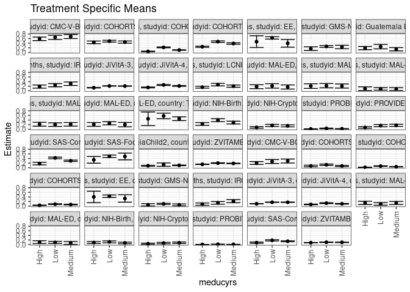

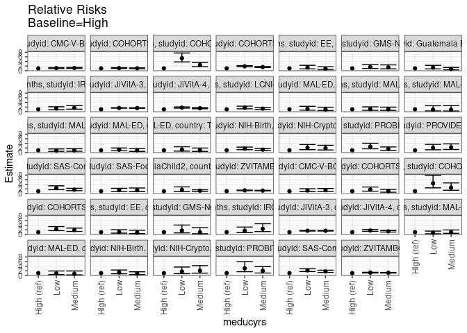

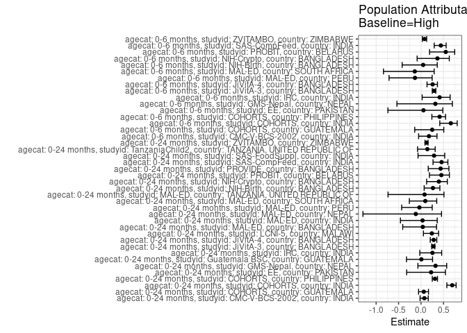

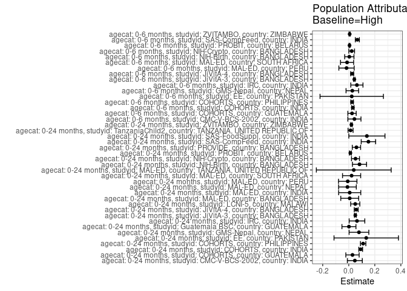

## Results Table

### Parameter: TSM

| agecat | studyid | country | intervention_level | baseline_level | estimate | ci_lower | ci_upper |
| --- | --- | --- | --- | --- | --- | --- | --- |
| 0-24 months | CMC-V-BCS-2002 | INDIA | High | NA | 0.5886076 | 0.5117753 | 0.6654398 |
| 0-24 months | CMC-V-BCS-2002 | INDIA | Low | NA | 0.6509434 | 0.5600782 | 0.7418086 |
| 0-24 months | CMC-V-BCS-2002 | INDIA | Medium | NA | 0.6880734 | 0.6009848 | 0.7751620 |
| 0-24 months | COHORTS | GUATEMALA | High | NA | 0.4350877 | 0.3775084 | 0.4926670 |
| 0-24 months | COHORTS | GUATEMALA | Low | NA | 0.4874214 | 0.4485604 | 0.5262824 |
| 0-24 months | COHORTS | GUATEMALA | Medium | NA | 0.4476190 | 0.4000462 | 0.4951919 |
| 0-24 months | COHORTS | INDIA | High | NA | 0.0403531 | 0.0266555 | 0.0540506 |
| 0-24 months | COHORTS | INDIA | Low | NA | 0.2177914 | 0.1994985 | 0.2360843 |
| 0-24 months | COHORTS | INDIA | Medium | NA | 0.1015147 | 0.0908876 | 0.1121417 |
| 0-24 months | COHORTS | PHILIPPINES | High | NA | 0.2455243 | 0.2208900 | 0.2701586 |
| 0-24 months | COHORTS | PHILIPPINES | Low | NA | 0.4673311 | 0.4347837 | 0.4998785 |
| 0-24 months | COHORTS | PHILIPPINES | Medium | NA | 0.3859470 | 0.3554940 | 0.4164001 |
| 0-24 months | EE | PAKISTAN | High | NA | 0.4666667 | 0.2138629 | 0.7194704 |
| 0-24 months | EE | PAKISTAN | Low | NA | 0.6280488 | 0.5756732 | 0.6804244 |
| 0-24 months | EE | PAKISTAN | Medium | NA | 0.3939394 | 0.2270064 | 0.5608724 |
| 0-24 months | GMS-Nepal | NEPAL | High | NA | 0.1647059 | 0.0857971 | 0.2436147 |
| 0-24 months | GMS-Nepal | NEPAL | Low | NA | 0.2592593 | 0.2202702 | 0.2982483 |
| 0-24 months | GMS-Nepal | NEPAL | Medium | NA | 0.2338710 | 0.1593139 | 0.3084281 |
| 0-24 months | Guatemala BSC | GUATEMALA | High | NA | 0.1864407 | 0.1160454 | 0.2568359 |
| 0-24 months | Guatemala BSC | GUATEMALA | Low | NA | 0.2500000 | 0.1524756 | 0.3475244 |
| 0-24 months | Guatemala BSC | GUATEMALA | Medium | NA | 0.1363636 | 0.0645358 | 0.2081915 |
| 0-24 months | IRC | INDIA | High | NA | 0.1854839 | 0.1169870 | 0.2539807 |
| 0-24 months | IRC | INDIA | Low | NA | 0.2448980 | 0.1752970 | 0.3144989 |
| 0-24 months | IRC | INDIA | Medium | NA | 0.3093525 | 0.2324172 | 0.3862879 |
| 0-24 months | JiVitA-3 | BANGLADESH | High | NA | 0.1340423 | 0.1260432 | 0.1420414 |
| 0-24 months | JiVitA-3 | BANGLADESH | Low | NA | 0.2116145 | 0.2032588 | 0.2199702 |
| 0-24 months | JiVitA-3 | BANGLADESH | Medium | NA | 0.2074949 | 0.1978468 | 0.2171430 |
| 0-24 months | JiVitA-4 | BANGLADESH | High | NA | 0.1462388 | 0.1287477 | 0.1637299 |
| 0-24 months | JiVitA-4 | BANGLADESH | Low | NA | 0.2560224 | 0.2335766 | 0.2784682 |
| 0-24 months | JiVitA-4 | BANGLADESH | Medium | NA | 0.2123485 | 0.1915917 | 0.2331053 |

[output cut: 93 more lines]

### Parameter: E(Y)

| agecat | studyid | country | intervention_level | baseline_level | estimate | ci_lower | ci_upper |
| --- | --- | --- | --- | --- | --- | --- | --- |
| 0-24 months | CMC-V-BCS-2002 | INDIA | NA | NA | 0.6353887 | 0.5864772 | 0.6843003 |
| 0-24 months | COHORTS | GUATEMALA | NA | NA | 0.4638330 | 0.4371320 | 0.4905339 |
| 0-24 months | COHORTS | INDIA | NA | NA | 0.1320916 | 0.1234158 | 0.1407674 |
| 0-24 months | COHORTS | PHILIPPINES | NA | NA | 0.3561151 | 0.3391405 | 0.3730897 |
| 0-24 months | EE | PAKISTAN | NA | NA | 0.6010638 | 0.5515023 | 0.6506253 |
| 0-24 months | GMS-Nepal | NEPAL | NA | NA | 0.2431655 | 0.2112486 | 0.2750823 |
| 0-24 months | Guatemala BSC | GUATEMALA | NA | NA | 0.1879433 | 0.1422658 | 0.2336207 |
| 0-24 months | IRC | INDIA | NA | NA | 0.2487805 | 0.2068840 | 0.2906770 |
| 0-24 months | JiVitA-3 | BANGLADESH | NA | NA | 0.1846063 | 0.1789984 | 0.1902143 |
| 0-24 months | JiVitA-4 | BANGLADESH | NA | NA | 0.2035431 | 0.1916695 | 0.2154167 |
| 0-24 months | LCNI-5 | MALAWI | NA | NA | 0.2076167 | 0.1797361 | 0.2354973 |
| 0-24 months | MAL-ED | BANGLADESH | NA | NA | 0.1869159 | 0.1345620 | 0.2392698 |
| 0-24 months | MAL-ED | INDIA | NA | NA | 0.2136364 | 0.1593519 | 0.2679208 |
| 0-24 months | MAL-ED | NEPAL | NA | NA | 0.0844444 | 0.0480318 | 0.1208571 |
| 0-24 months | MAL-ED | PERU | NA | NA | 0.2119205 | 0.1657530 | 0.2580880 |
| 0-24 months | MAL-ED | SOUTH AFRICA | NA | NA | 0.2324841 | 0.1856873 | 0.2792809 |
| 0-24 months | MAL-ED | TANZANIA, UNITED REPUBLIC OF | NA | NA | 0.4930876 | 0.4264146 | 0.5597605 |
| 0-24 months | NIH-Birth | BANGLADESH | NA | NA | 0.3116057 | 0.2753823 | 0.3478292 |
| 0-24 months | NIH-Crypto | BANGLADESH | NA | NA | 0.1306069 | 0.1066024 | 0.1546113 |
| 0-24 months | PROBIT | BELARUS | NA | NA | 0.0276380 | 0.0201988 | 0.0350773 |
| 0-24 months | PROVIDE | BANGLADESH | NA | NA | 0.1357143 | 0.1103250 | 0.1611036 |
| 0-24 months | SAS-CompFeed | INDIA | NA | NA | 0.3307241 | 0.3024794 | 0.3589688 |
| 0-24 months | SAS-FoodSuppl | INDIA | NA | NA | 0.4808612 | 0.4329065 | 0.5288160 |
| 0-24 months | TanzaniaChild2 | TANZANIA, UNITED REPUBLIC OF | NA | NA | 0.0993294 | 0.0873254 | 0.1113334 |
| 0-24 months | ZVITAMBO | ZIMBABWE | NA | NA | 0.1682795 | 0.1620941 | 0.1744649 |
| 0-6 months | CMC-V-BCS-2002 | INDIA | NA | NA | 0.2472826 | 0.2031431 | 0.2914222 |
| 0-6 months | COHORTS | GUATEMALA | NA | NA | 0.1011132 | 0.0831080 | 0.1191183 |
| 0-6 months | COHORTS | INDIA | NA | NA | 0.0473331 | 0.0418015 | 0.0528647 |
| 0-6 months | COHORTS | PHILIPPINES | NA | NA | 0.0624591 | 0.0538810 | 0.0710373 |
| 0-6 months | EE | PAKISTAN | NA | NA | 0.4228723 | 0.3728720 | 0.4728727 |
| 0-6 months | GMS-Nepal | NEPAL | NA | NA | 0.0863309 | 0.0654358 | 0.1072261 |
| 0-6 months | IRC | INDIA | NA | NA | 0.1512195 | 0.1164988 | 0.1859402 |
| 0-6 months | JiVitA-3 | BANGLADESH | NA | NA | 0.1475283 | 0.1424745 | 0.1525821 |
| 0-6 months | JiVitA-4 | BANGLADESH | NA | NA | 0.1013500 | 0.0923758 | 0.1103243 |
| 0-6 months | MAL-ED | PERU | NA | NA | 0.1258278 | 0.0883606 | 0.1632951 |
| 0-6 months | MAL-ED | SOUTH AFRICA | NA | NA | 0.0923567 | 0.0602816 | 0.1244318 |
| 0-6 months | NIH-Birth | BANGLADESH | NA | NA | 0.0937997 | 0.0709973 | 0.1166021 |
| 0-6 months | NIH-Crypto | BANGLADESH | NA | NA | 0.0620053 | 0.0448256 | 0.0791849 |
| 0-6 months | PROBIT | BELARUS | NA | NA | 0.0109519 | 0.0074064 | 0.0144975 |
| 0-6 months | SAS-CompFeed | INDIA | NA | NA | 0.1496732 | 0.1307571 | 0.1685893 |
| 0-6 months | ZVITAMBO | ZIMBABWE | NA | NA | 0.0913301 | 0.0865643 | 0.0960959 |

### Parameter: RR

| agecat | studyid | country | intervention_level | baseline_level | estimate | ci_lower | ci_upper |
| --- | --- | --- | --- | --- | --- | --- | --- |
| 0-24 months | CMC-V-BCS-2002 | INDIA | High | High | 1.0000000 | 1.0000000 | 1.000000 |
| 0-24 months | CMC-V-BCS-2002 | INDIA | Low | High | 1.1059038 | 0.9135203 | 1.338802 |
| 0-24 months | CMC-V-BCS-2002 | INDIA | Medium | High | 1.1689849 | 0.9746433 | 1.402078 |
| 0-24 months | COHORTS | GUATEMALA | High | High | 1.0000000 | 1.0000000 | 1.000000 |
| 0-24 months | COHORTS | GUATEMALA | Low | High | 1.1202830 | 0.9599071 | 1.307454 |
| 0-24 months | COHORTS | GUATEMALA | Medium | High | 1.0288018 | 0.8681961 | 1.219118 |
| 0-24 months | COHORTS | INDIA | High | High | 1.0000000 | 1.0000000 | 1.000000 |
| 0-24 months | COHORTS | INDIA | Low | High | 5.3971434 | 3.8045213 | 7.656458 |
| 0-24 months | COHORTS | INDIA | Medium | High | 2.5156602 | 1.7635291 | 3.588569 |
| 0-24 months | COHORTS | PHILIPPINES | High | High | 1.0000000 | 1.0000000 | 1.000000 |
| 0-24 months | COHORTS | PHILIPPINES | Low | High | 1.9034007 | 1.6845626 | 2.150668 |
| 0-24 months | COHORTS | PHILIPPINES | Medium | High | 1.5719302 | 1.3835619 | 1.785944 |
| 0-24 months | EE | PAKISTAN | High | High | 1.0000000 | 1.0000000 | 1.000000 |
| 0-24 months | EE | PAKISTAN | Low | High | 1.3458188 | 0.7779437 | 2.328225 |
| 0-24 months | EE | PAKISTAN | Medium | High | 0.8441558 | 0.4243530 | 1.679260 |
| 0-24 months | GMS-Nepal | NEPAL | High | High | 1.0000000 | 1.0000000 | 1.000000 |
| 0-24 months | GMS-Nepal | NEPAL | Low | High | 1.5740741 | 0.9526851 | 2.600764 |
| 0-24 months | GMS-Nepal | NEPAL | Medium | High | 1.4199309 | 0.7986324 | 2.524570 |
| 0-24 months | Guatemala BSC | GUATEMALA | High | High | 1.0000000 | 1.0000000 | 1.000000 |
| 0-24 months | Guatemala BSC | GUATEMALA | Low | High | 1.3409091 | 0.7791508 | 2.307688 |
| 0-24 months | Guatemala BSC | GUATEMALA | Medium | High | 0.7314050 | 0.3825585 | 1.398357 |
| 0-24 months | IRC | INDIA | High | High | 1.0000000 | 1.0000000 | 1.000000 |
| 0-24 months | IRC | INDIA | Low | High | 1.3203194 | 0.8285199 | 2.104045 |
| 0-24 months | IRC | INDIA | Medium | High | 1.6678136 | 1.0685368 | 2.603188 |
| 0-24 months | JiVitA-3 | BANGLADESH | High | High | 1.0000000 | 1.0000000 | 1.000000 |
| 0-24 months | JiVitA-3 | BANGLADESH | Low | High | 1.5787139 | 1.4766317 | 1.687853 |
| 0-24 months | JiVitA-3 | BANGLADESH | Medium | High | 1.5479804 | 1.4380540 | 1.666310 |
| 0-24 months | JiVitA-4 | BANGLADESH | High | High | 1.0000000 | 1.0000000 | 1.000000 |
| 0-24 months | JiVitA-4 | BANGLADESH | Low | High | 1.7507144 | 1.5116197 | 2.027627 |
| 0-24 months | JiVitA-4 | BANGLADESH | Medium | High | 1.4520667 | 1.2436701 | 1.695384 |

[output cut: 93 more lines]

### Parameter: PAR

| agecat | studyid | country | intervention_level | baseline_level | estimate | ci_lower | ci_upper |
| --- | --- | --- | --- | --- | --- | --- | --- |
| 0-24 months | CMC-V-BCS-2002 | INDIA | High | NA | 0.0467811 | -0.0106160 | 0.1041783 |
| 0-24 months | COHORTS | GUATEMALA | High | NA | 0.0287452 | -0.0224319 | 0.0799224 |
| 0-24 months | COHORTS | INDIA | High | NA | 0.0917385 | 0.0771768 | 0.1063002 |
| 0-24 months | COHORTS | PHILIPPINES | High | NA | 0.1105908 | 0.0898681 | 0.1313135 |
| 0-24 months | EE | PAKISTAN | High | NA | 0.1343972 | -0.1131243 | 0.3819187 |
| 0-24 months | GMS-Nepal | NEPAL | High | NA | 0.0784596 | 0.0028141 | 0.1541050 |
| 0-24 months | Guatemala BSC | GUATEMALA | High | NA | 0.0015026 | -0.0523005 | 0.0553056 |
| 0-24 months | IRC | INDIA | High | NA | 0.0632966 | 0.0032203 | 0.1233729 |
| 0-24 months | JiVitA-3 | BANGLADESH | High | NA | 0.0505640 | 0.0439754 | 0.0571526 |
| 0-24 months | JiVitA-4 | BANGLADESH | High | NA | 0.0573043 | 0.0423538 | 0.0722547 |
| 0-24 months | LCNI-5 | MALAWI | High | NA | 0.0498986 | 0.0147346 | 0.0850626 |
| 0-24 months | MAL-ED | BANGLADESH | High | NA | 0.0074287 | -0.0612440 | 0.0761014 |
| 0-24 months | MAL-ED | INDIA | High | NA | 0.0072872 | -0.0777598 | 0.0923342 |
| 0-24 months | MAL-ED | NEPAL | High | NA | -0.0098952 | -0.0778345 | 0.0580441 |
| 0-24 months | MAL-ED | PERU | High | NA | -0.0078597 | -0.0786926 | 0.0629732 |
| 0-24 months | MAL-ED | SOUTH AFRICA | High | NA | 0.0219578 | -0.0477019 | 0.0916174 |
| 0-24 months | MAL-ED | TANZANIA, UNITED REPUBLIC OF | High | NA | 0.0385421 | -0.2488804 | 0.3259646 |
| 0-24 months | NIH-Birth | BANGLADESH | High | NA | 0.0825554 | 0.0282647 | 0.1368462 |
| 0-24 months | NIH-Crypto | BANGLADESH | High | NA | 0.0518667 | 0.0212313 | 0.0825021 |
| 0-24 months | PROBIT | BELARUS | High | NA | 0.0124972 | 0.0050015 | 0.0199929 |
| 0-24 months | PROVIDE | BANGLADESH | High | NA | 0.0591185 | 0.0271022 | 0.0911349 |
| 0-24 months | SAS-CompFeed | INDIA | High | NA | 0.1511575 | 0.0956574 | 0.2066576 |
| 0-24 months | SAS-FoodSuppl | INDIA | High | NA | 0.1393978 | 0.0005604 | 0.2782352 |
| 0-24 months | TanzaniaChild2 | TANZANIA, UNITED REPUBLIC OF | High | NA | 0.0139832 | -0.0054003 | 0.0333667 |
| 0-24 months | ZVITAMBO | ZIMBABWE | High | NA | 0.0205880 | 0.0148547 | 0.0263213 |
| 0-6 months | CMC-V-BCS-2002 | INDIA | High | NA | 0.0434610 | -0.0068633 | 0.0937852 |
| 0-6 months | COHORTS | GUATEMALA | High | NA | 0.0252203 | -0.0068380 | 0.0572787 |
| 0-6 months | COHORTS | INDIA | High | NA | 0.0313968 | 0.0219452 | 0.0408485 |
| 0-6 months | COHORTS | PHILIPPINES | High | NA | 0.0258010 | 0.0157750 | 0.0358270 |
| 0-6 months | EE | PAKISTAN | High | NA | 0.0228723 | -0.2204591 | 0.2662038 |
| 0-6 months | GMS-Nepal | NEPAL | High | NA | 0.0275074 | -0.0207563 | 0.0757711 |
| 0-6 months | IRC | INDIA | High | NA | 0.0625098 | 0.0156325 | 0.1093872 |
| 0-6 months | JiVitA-3 | BANGLADESH | High | NA | 0.0429146 | 0.0370821 | 0.0487471 |
| 0-6 months | JiVitA-4 | BANGLADESH | High | NA | 0.0261830 | 0.0144409 | 0.0379250 |
| 0-6 months | MAL-ED | PERU | High | NA | -0.0170293 | -0.0758897 | 0.0418310 |
| 0-6 months | MAL-ED | SOUTH AFRICA | High | NA | -0.0129065 | -0.0632808 | 0.0374679 |
| 0-6 months | NIH-Birth | BANGLADESH | High | NA | 0.0044142 | -0.0312754 | 0.0401038 |
| 0-6 months | NIH-Crypto | BANGLADESH | High | NA | 0.0226352 | 0.0006343 | 0.0446361 |
| 0-6 months | PROBIT | BELARUS | High | NA | 0.0060224 | 0.0019918 | 0.0100529 |
| 0-6 months | SAS-CompFeed | INDIA | High | NA | 0.0660819 | 0.0504749 | 0.0816888 |
| 0-6 months | ZVITAMBO | ZIMBABWE | High | NA | 0.0071762 | 0.0027719 | 0.0115805 |

### Parameter: PAF

| agecat | studyid | country | intervention_level | baseline_level | estimate | ci_lower | ci_upper |
| --- | --- | --- | --- | --- | --- | --- | --- |
| 0-24 months | CMC-V-BCS-2002 | INDIA | High | NA | 0.0736260 | -0.0216950 | 0.1600539 |
| 0-24 months | COHORTS | GUATEMALA | High | NA | 0.0619733 | -0.0551536 | 0.1660985 |
| 0-24 months | COHORTS | INDIA | High | NA | 0.6945068 | 0.5743646 | 0.7807369 |
| 0-24 months | COHORTS | PHILIPPINES | High | NA | 0.3105479 | 0.2503186 | 0.3659385 |
| 0-24 months | EE | PAKISTAN | High | NA | 0.2235988 | -0.3205244 | 0.5435156 |
| 0-24 months | GMS-Nepal | NEPAL | High | NA | 0.3226592 | -0.0696004 | 0.5710637 |
| 0-24 months | Guatemala BSC | GUATEMALA | High | NA | 0.0079949 | -0.3238570 | 0.2566613 |
| 0-24 months | IRC | INDIA | High | NA | 0.2544276 | -0.0280824 | 0.4593057 |
| 0-24 months | JiVitA-3 | BANGLADESH | High | NA | 0.2739018 | 0.2375884 | 0.3084857 |
| 0-24 months | JiVitA-4 | BANGLADESH | High | NA | 0.2815338 | 0.2051690 | 0.3505618 |
| 0-24 months | LCNI-5 | MALAWI | High | NA | 0.2403399 | 0.0529273 | 0.3906662 |
| 0-24 months | MAL-ED | BANGLADESH | High | NA | 0.0397436 | -0.4076927 | 0.3449619 |
| 0-24 months | MAL-ED | INDIA | High | NA | 0.0341101 | -0.4584861 | 0.3603345 |
| 0-24 months | MAL-ED | NEPAL | High | NA | -0.1171797 | -1.2929418 | 0.4556815 |
| 0-24 months | MAL-ED | PERU | High | NA | -0.0370879 | -0.4314167 | 0.2486106 |
| 0-24 months | MAL-ED | SOUTH AFRICA | High | NA | 0.0944484 | -0.2603274 | 0.3493567 |
| 0-24 months | MAL-ED | TANZANIA, UNITED REPUBLIC OF | High | NA | 0.0781648 | -0.7350273 | 0.5102209 |
| 0-24 months | NIH-Birth | BANGLADESH | High | NA | 0.2649356 | 0.0694820 | 0.4193345 |
| 0-24 months | NIH-Crypto | BANGLADESH | High | NA | 0.3971208 | 0.1242822 | 0.5849538 |
| 0-24 months | PROBIT | BELARUS | High | NA | 0.4521737 | 0.1866302 | 0.6310244 |
| 0-24 months | PROVIDE | BANGLADESH | High | NA | 0.4356103 | 0.1606001 | 0.6205197 |
| 0-24 months | SAS-CompFeed | INDIA | High | NA | 0.4570502 | 0.2671526 | 0.5977410 |
| 0-24 months | SAS-FoodSuppl | INDIA | High | NA | 0.2898920 | -0.0670519 | 0.5274331 |
| 0-24 months | TanzaniaChild2 | TANZANIA, UNITED REPUBLIC OF | High | NA | 0.1407761 | -0.0775497 | 0.3148662 |
| 0-24 months | ZVITAMBO | ZIMBABWE | High | NA | 0.1223440 | 0.0878037 | 0.1555765 |
| 0-6 months | CMC-V-BCS-2002 | INDIA | High | NA | 0.1757542 | -0.0536584 | 0.3552169 |
| 0-6 months | COHORTS | GUATEMALA | High | NA | 0.2494266 | -0.1411527 | 0.5063234 |
| 0-6 months | COHORTS | INDIA | High | NA | 0.6633169 | 0.4174954 | 0.8053998 |
| 0-6 months | COHORTS | PHILIPPINES | High | NA | 0.4130859 | 0.2408869 | 0.5462228 |
| 0-6 months | EE | PAKISTAN | High | NA | 0.0540881 | -0.7380042 | 0.4851857 |
| 0-6 months | GMS-Nepal | NEPAL | High | NA | 0.3186275 | -0.5372684 | 0.6979912 |
| 0-6 months | IRC | INDIA | High | NA | 0.4133715 | 0.0245889 | 0.6471918 |
| 0-6 months | JiVitA-3 | BANGLADESH | High | NA | 0.2908908 | 0.2506420 | 0.3289777 |
| 0-6 months | JiVitA-4 | BANGLADESH | High | NA | 0.2583422 | 0.1330813 | 0.3655042 |
| 0-6 months | MAL-ED | PERU | High | NA | -0.1353383 | -0.7124458 | 0.2472795 |
| 0-6 months | MAL-ED | SOUTH AFRICA | High | NA | -0.1397459 | -0.8365787 | 0.2926953 |
| 0-6 months | NIH-Birth | BANGLADESH | High | NA | 0.0470599 | -0.4203868 | 0.3606708 |
| 0-6 months | NIH-Crypto | BANGLADESH | High | NA | 0.3650528 | -0.0869864 | 0.6291049 |
| 0-6 months | PROBIT | BELARUS | High | NA | 0.5498896 | 0.1900798 | 0.7498527 |
| 0-6 months | SAS-CompFeed | INDIA | High | NA | 0.4415077 | 0.2932870 | 0.5586417 |
| 0-6 months | ZVITAMBO | ZIMBABWE | High | NA | 0.0785742 | 0.0292156 | 0.1254233 |